# Trees

Alípio Jorge

March 2021

# Learning with trees

Linear regression, Logistic Regression, Discriminant Analysis

- Strong model assumption (high bias)
- Low variance
- Powerful theoretical properties

Nearest Neighbor

- No model
- Highly adaptable
- bias and variance depend on the **hyper parameter** $~k$

# Learning with trees

- **Advantages** of Linear Regression and kNN:
  - No search required
  - Simple hyper parameter (in the case of kNN)
- **Disadvantages**
  - **Transparency**
    - readability,
    - explanations,
    - etc.

# Learning with trees

- Let us consider a simple **regression problem**

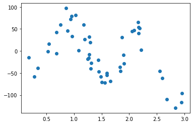

```python
import numpy as np
from numpy.random import seed
from numpy.random import rand
from numpy.random import normal
import matplotlib.pyplot as plt

def hf(x):
    return 8-x**2-50*np.sin(x*5)-x**4

seed(123)
x = rand(50)*3
y = hf(x)+normal(size=50,scale=20)
plt.scatter(x,y);
```

# Learning with trees

- We now run a regression tree algorithm on this data.

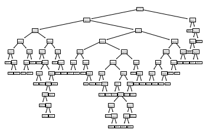

```python
from sklearn.tree import DecisionTreeRegressor as DTR
from sklearn.tree import plot_tree

model=DTR().fit(x[:,np.newaxis],y)
plot_tree(model);
```

# Learning with trees

- Which **function** did we learn? A step function.
- What do we observe?
  - The tree model is highly expressive / **complex**
  - Probably **overfits**

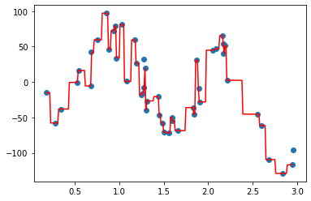

```python
x_plot = np.arange(min(x),max(x),0.01)
plt.scatter(x,y)
plt.plot(x_plot,model.predict(x_plot[:,np.newaxis]),c='red');
```

# Learning with trees

- We can reduce the complexity using hyperparameters
  - Maximum depth of the tree
  - Minimum number of cases in a leave
  - Tree complexity
    - smaller trees are preferred

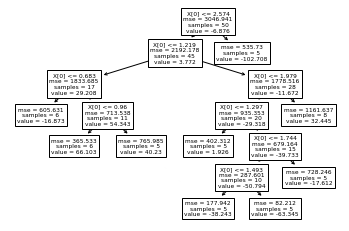

```python
model=DTR(min_samples_leaf=5).fit(x[:,np.newaxis],y)
plot_tree(model);
```

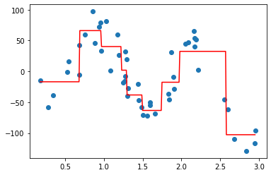

```python
plt.scatter(x,y)
plt.plot(x_plot,model.predict(x_plot[:,np.newaxis]),c='red');
```

# Defining a function with trees

- How does a tree **define** a function?
- The tree **divides** the input space in **regions**
  - The input space is recursively partitioned
  - Each partition is a hyper-rectangles (in general)
- In each region $f(x)$ is **constant**.
  - In regression or classification

# Defining a function with trees

- **Example:** Let us see how it work with iris (2 predictors)
  - load iris
  - build tree with minimum number of examples in leaf set to 2
  - look at the tree
  - look at the boundary

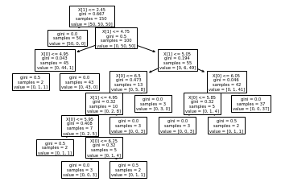

```python
from sklearn.datasets import load_iris
from sklearn.tree import DecisionTreeClassifier as DTC
iris=load_iris()
X=iris.data[:,[0,2]]
y=iris.target
model=DTC(min_samples_leaf=2).fit(X,y)
plot_tree(model);
```

```python
from matplotlib import colors

def plot_classifier_boundary(model,X,y,h = .05):
    # this function can be used with any sklearn classifier
    # ready for two classes but can be easily extended
    cmap_light = colors.ListedColormap(['lightsteelblue', 'peachpuff','lightgreen'])
    x_min, x_max = X[:, 0].min()-.2, X[:, 0].max()+.2
    y_min, y_max = X[:, 1].min()-.2, X[:, 1].max()+.2
    # generate a grid with step h
    xx, yy = np.meshgrid(np.arange(x_min, x_max, h),
                         np.arange(y_min, y_max, h))
    # the method ravel flattens xx and yy
    Z = model.predict(np.c_[xx.ravel(), yy.ravel()])
    Z = Z.reshape(xx.shape)
    plt.contourf(xx, yy, Z, cmap=cmap_light)
    plt.xlim((x_min,x_max))
    plt.ylim((y_min,y_max))
```

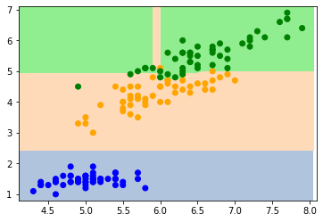

```python
cmap = colors.ListedColormap(['blue','orange','green'])

plot_classifier_boundary(model,X,y)
plt.scatter(X[:,0],X[:,1],color=cmap(y))
```

# Defining a function with trees

- We now define the tree function **mathematically**
- The function to be learned by the tree has the general form

  $$ f(x) = \sum_{m=1}^{M} c_m . I(x \in R_m) $$
- where $I(true)=1, I(false)=0$
- The constant can be estimated as

$$ \hat{c}_m = ave(y_i | x_i \in R_m) $$

- The aim is to find the tree that **minimizes error**
  - Typically we minimize **entropy**
  - We will see that in general we **do not find a global optimum**

# Learning a tree model

How can the tree be **learned**?

- Finding the best partitioning is **not solved analytically**
- A **search procedure** has to be used
- It is unfeasible to consider all possible partitionings
- We use **heuristic search** to look for a tree
  - Typically **greedy search**
    - **hill climbing**
    - No global optimum guaranteed
  - Most popular approach: **TDIDT**
    - top down induction of decision trees
    - CART, ID3, C4.5

# Learning a tree model

- A **TDIDT** algorithm (Top Down Induction of Decision Trees)
  1. start with all the data $D$
  2. find the **test** that minimizes the **combined error** of both new regions
     - e.g. $x_7 > 0.42$
     - only makes sense if error reduces
  3. apply the procedure to each new region until stopping criteria are met
- Possible **stopping criteria**:
  - minimum number of examples in region; maximum depth of tree; error of region does not decrease after split

# Learning a tree model

- The classical error measure in TDIDT is **entropy**
  - The degree of **confusion** we have in the set of examples
  - How many **bits** we need to classify each example (in average)?
- If we have **2 classes equally distributed** Entropy is 1

$$ Entropy = \sum_{k \in Classes} -p_k log(p_k) $$

- The measure that represents error minimization of a test $t$ that splits a set of $n$ cases $X$ in $k$ nodes is **Information Gain**

$$ IG(X,t) = Entropy(X) - \sum_{i \in k}\frac{n_i}n Entropy(X_i) $$

```python
csizes=np.array([50,50])
n=sum(csizes)
entropy=sum(-csizes/n*np.log2(csizes/n))
entropy
```

```
1.0
```

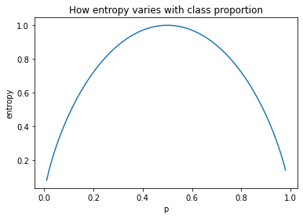

```python
def entropy2(p=0.5):
    q=1-p
    return -p*np.log2(p)-q*np.log2(q)

p=np.arange(0.01,0.99,0.01)
plt.plot(p,entropy2(p))
plt.title('How entropy varies with class proportion')
plt.xlabel('p')
plt.ylabel('entropy');
```

# Learning a tree model

- **Example** with 2 classes <50,50>
  - Entropy is 1 (T0)
  - If we have 2 candidate tests T1 and T2
    - with T1 the split is <20,10> and <30,40>
    - with T2 the split is <5,25> and <45,25>
- Entropies after split
  - T1 = 0.965
  - T2 = 0.853
- Information gain
  - T0-T1 = 0.035
  - T0-T2 = 0.147 *

```python
#T1
csizes=np.array([[20,10],[30,40]])
w0=sum(csizes[0,:])/sum(sum(csizes))
w1=sum(csizes[1,:])/sum(sum(csizes))
p0=csizes[0,0]/sum(csizes[0,:])
p1=csizes[1,0]/sum(csizes[1,:])
ent0=entropy2(p0)
ent1=entropy2(p1)
print((w0,ent0,w1,ent1))
entT1=w0*ent0+w1*ent1
print((entT1, 1-entT1))

#T2
csizes=np.array([[5,25],[45,25]])
w0=sum(csizes[0,:])/sum(sum(csizes))
w1=sum(csizes[1,:])/sum(sum(csizes))
p0=csizes[0,0]/sum(csizes[0,:])
p1=csizes[1,0]/sum(csizes[1,:])
ent0=entropy2(p0)
ent1=entropy2(p1)
print((w0,ent0,w1,ent1))
entT2=w0*ent0+w1*ent1
print((entT2,1-entT2))
```

```
(0.3, 0.9182958340544896, 0.7, 0.9852281360342515)
(0.965148445440323, 0.034851554559677034)
(0.3, 0.6500224216483541, 0.7, 0.9402859586706311)
(0.853206897563948, 0.14679310243605204)
```

# Learning a tree model > error measures

- Which **error measures** can be used when **growing** the tree?
- **Classification**
  - Misclassification error averaged over regions
  - Each region has a most likely class with probability $p_k$
    - **Gini index**:
      - sum of $p_k(1-p_k)$ over the classes
    - **Cross-entropy**
      - sum of $~-p_k log(p_k)$ over the classes
    - **Zero-one**
      - Not commonly used. It is less sensitive than Entropy
        - (https://sebastianraschka.com/faq/docs/decisiontree-error-vs-entropy.html)
- **Regression**
  - Prediction error
    - Mean Squared Error **MSE**
    - Mean Average Error **MAE**
    - Other error/loss functions

# Learning a tree model > Maximum Likelihood Estimate

- For each region, assuming that the local function is a constant:
  - the **Maximum Likelihood Estimate** for $~c_{region}~$ is the average/mode of the values of $~y$ in that region
  - each split **minimizes the error** under the specific set of options
  - the global error of the tree found (learned function) is a **local optimum** not guaranteed to be global
- Some methods learn a **local model** in the region (e.g. a linear model)
  - what may be the problem with this approach?

# Learning a tree model > selecting tests for splits

- When we are at a node with $n$ cases we have to find the **test** with the best **split**
  - Which are the candidate tests?
    - We will use the Golf dataset for examples
- **Categorical** input variables (predictors)
  - For **binary** variables we one candidate test
    - Attribute `windy`
      - This gives one split
  - For **multivalued** variables we have one candidate per value
    - Attribute `outlook` with values `sunny`, `overcast` and `rain`
      - 3 splits
  - For **multivalued** variables we can also group their values in two sets
    - Regression: sort the values by outcome (mean of $y_{region}$)
    - Classification: sort by class proportion

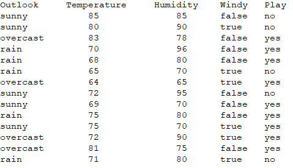

```python
from IPython.display import Image
Image("imagens/Golf_data.png")
```

# Learning a tree model > selecting tests for splits

- **Numerical** input variables
  - Classification: **Sort** the variable $x$ and find **candidate thresholds** $\theta_i$
    - Every time the class changes **consistently**
    - **Candidate tests** are $x > \theta_i$
    - **Example**: `Temperature`

# Learning a tree model > selecting tests for splits

- Variables with many values tend to be artificially **favoured**
  - many values yield many partitions
  - the more partitions we have the more choices
  - the more choices, the more **overfitting**
  - Instead of **Information Gain** we can use **Information Gain Ratio** $IGR$

$$ IGR(X,t) = \frac{IG(X,t)}{IntrinsicValueV(X,t)} $$$$ IntrinsicValueV(X,t) = - \sum_{i \in k}\frac{n_i}n log_2(\frac{n_i}n) $$

# Learning a tree model > complexity

- If we have $N$ data points what is the **computational complexity** of computing a split for a regression problem?
  - $O(N)$
- And for multilevel trees?
  - tree has maximum depth $d$ : $O(N\cdot d)$
  - assuming the splits tend to be in the middle : $O(N\cdot log_2(N))$
  - in the case of unbalanced splits : $O(N^2)$
- What is the computational complexity if we have $p$ variables?
  - $O(p \cdot N \cdot log_2(N))$
- But remember we have to **sort** the data

# Learning a tree model > pruning

- How **large** should the tree be?
  - A too large tree might **overfit** the data.
  - A too small tree may **underfit**
  - Tree size is controled by **tuning parameters** (hyper parameters)
    - maxdepth, minsplit, minbucket, cp (complexity parameter)
  - These can be estimated using cross-validation (no formulae)
- We can **stop growing a tree** or we can overgrow the tree and then cut parts of it (**pruning**)

# Learning a tree model > pruning

- A general pruning criterion is the cost complexity $C_\alpha$
  - complexity penalizes larger trees ($T$)

$$ C_\alpha(T) = \sum_{m=1}^{|T|}N_m Q_m(T) + \alpha|T| $$

- where $N_m$ is the size of the region, $Q_m$ is the error of the region.
- The $\alpha$ coefficient tunes complexity
  - $\alpha=0$ implies that there is no penalization
  - this can be used in **post-pruning**

# Learning with trees > cost-complexity

- In `sklearn`, `ccp_alpha` is the **cost-complexity** parameter ($\alpha$)
  - It is used to control the **growth** of the tree $T$ taking into account:
    - Impurity of the terminal nodes $R(T)$
    - Number of terminal nodes $|\widetilde{T}|$ or **leaves**

$$ R_\alpha(T) = R(T) + \alpha|\widetilde{T}| $$

- $R(T)$ can be measured as total sample weighted impurity of terminal nodes.
- In a tree we can **prune** any subtree $T_t$ of a node $t$
  - Each non-terminal node $t$ has a subtree $T_t$
  - If $R_{\alpha}(T_t) \geq R_{\alpha}(t)$ the $T_t$ is pruned
- The larger the $\alpha$ the **harder** it is to grow the tree
  - $\alpha = 0$ means we don't care about the size of the sub-tree, we only care about **error** or impurity

(https://scikit-learn.org/stable/modules/tree.html#minimal-cost-complexity-pruning)

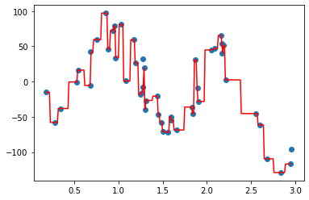

```python
seed(123)
x = rand(50)*3
y = hf(x)+normal(size=50,scale=20)

# try different values for the cost-complexity parameter of the Decision Tree Regressor
model=DTR(ccp_alpha=0).fit(x[:,np.newaxis],y)

x_plot = np.arange(min(x),max(x),0.01)
plt.scatter(x,y)
plt.plot(x_plot,model.predict(x_plot[:,np.newaxis]),c='red');
```

# Trees > Summary so far

- We can **define functions** using decision trees
  - classifiers and regressors
- In **operation**, a DT divides the input space in regions
  - In each region the $\hat{y}$ is constant
- A DT can be **learned from data**
  - There is no analytic solution
    - We need a **search procedure**
  - The search space is very large
    - We use **heuristic search**
    - Very **efficient**
    - Solution may not be a global **optimum**
  - Algorithms are in the TDIDT family
    - At each node/region choose the **best test**
    - The test **splits** the data in the node in $k$ nodes/regions
    - For each resulting node choose a constant value for $\hat{y}$
    - The constant chosen is the one that optimizes **MLE**

# Trees > Are they any good?

- Trees are **human readable**
  - We can obtain **if-then** rules from trees
    - If it is overcast I can go play golf
- **How good** are decision trees for machine learning?
  - They can be useful
  - They are improved by **ensemble approaches**
  - They are not good with low level data
    - They can grow very large
  - But it always depends on the problem

# Learning with trees > Bagging

- Bagging (**Bootstrap Aggregation**) is an **ensemble** technique
  - Obtain $B$ bootstrap samples from the dataset
  - Learn a DT from each sample
  - Predict by **averaging** the response of the $B$ models
- Bagging can improve the result of decision trees.
  - The resulting model can more quickly adapt to the data
  - Averaging of the models **reduces variance**
- Example
  - Single tree tries to hit every example
  - Bagging tries to find a midway

[figure not shown]

```python
from sklearn.ensemble import BaggingRegressor as BagR

seed(123)
x = rand(50)*3
y = hf(x)+normal(size=50,scale=20)

modelBag=BagR(n_estimators=100).fit(x[:,np.newaxis],y)
modelTree=DTR().fit(x[:,np.newaxis],y)

x_plot = np.arange(min(x),max(x),0.01)
plt.scatter(x,y)
plt.title("DT in red, Bagging in green")
plt.plot(x_plot,modelBag.predict(x_plot[:,np.newaxis]),c='green');
#plt.plot(x_plot,modelTree.predict(x_plot[:,np.newaxis]),c='red');
```

- The **base model** for Bagging
  - Can have specified hyper-parameters
  - Can be other than decision trees
- The example below illustrates
  - variance reduction: bagging avoids extreme values
    - Bagging **reduces variance**
  - increased expressivity **with respect of a tree with the same size**
    - In theory baggin **does not** reduce bias

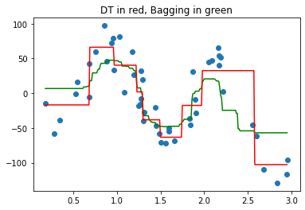

```python
modelBag=BagR(DTR(min_samples_leaf=5),n_estimators=100).fit(x[:,np.newaxis],y)
modelTree=DTR(min_samples_leaf=5).fit(x[:,np.newaxis],y)

x_plot = np.arange(min(x),max(x),0.01)
plt.scatter(x,y)
plt.title("DT in red, Bagging in green")
plt.plot(x_plot,modelBag.predict(x_plot[:,np.newaxis]),c='green');
plt.plot(x_plot,modelTree.predict(x_plot[:,np.newaxis]),c='red');
```

# Learning with trees > Bagging

- What was the effect of bagging with respect to:
  - variance error ?
  - bias error ?
  - expressiveness ?
  - transparency ?

# Learning with trees > Bagging

- Why does Bagging reduce variance?
  - in general, for a random variable $X$

$$ Var(\overline{X}) = \frac{Var(X)}N $$

- In the best case

$$ Var(Bagging{L(X,f(X))}) = \frac{Var(L(X,f(X)))}N $$

- **However** the variance of the average is, in general(ESL, ch. 15)
  - ($\rho$ is the correlation between samples)

$$ \rho Var(\overline{X}) + \frac{1-\rho}{N} Var(X) $$

- **In conclusion**
  - In Bagging **models are correlated** ($\rho > 0$)
  - So, variance reduction is **actually smaller** than the best case (where $\rho = 0$)
  - If $L(X,f(X))$ is stable (e.g. linear regression, with small variance) then **effect of Bagging can be negligible**

# Bibliography

- The Elements of Statistical Learning, Hastie, Trevor, Tibshirani, Robert, Friedman, Jerome, Springer.
- sklearn documentation
- Other sources mentioned in the notes